# Homework #09

Robert Campbell

26 Apr 2021

## Chapter 09

### Problem 02

```r
2*sum(dsignrank(601:1000,40))
```

```
## [1] 0.009381349
```

### Problem 04

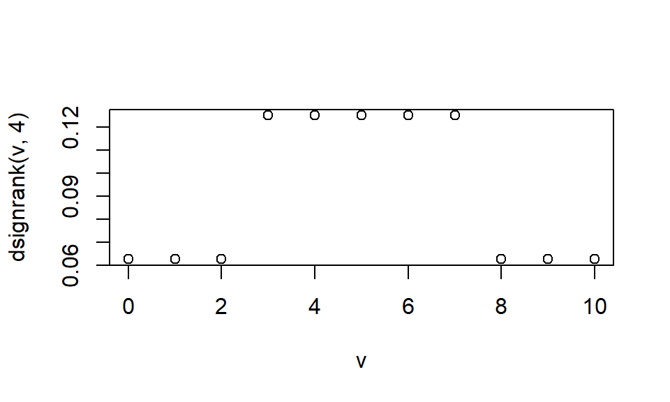

```r
x <- c(-1,0,2,8)
mu <- 3
xdif <- x-mu
xrank<-rank(abs(xdif))
#sum(xrank[xdif > 0])
v<-0:10
plot(v,dsignrank(v,4))
```

```r
2*(sum(dsignrank(0:4, 4)))
```

```
## [1] 0.875
```

```r
wilcox.test(x, mu=mu)
```

```
##
##  Wilcoxon signed rank exact test
##
## data:  x
## V = 4, p-value = 0.875
## alternative hypothesis: true location is not equal to 3
```

### Problem 06

1. The data seems reasonably symmetric.

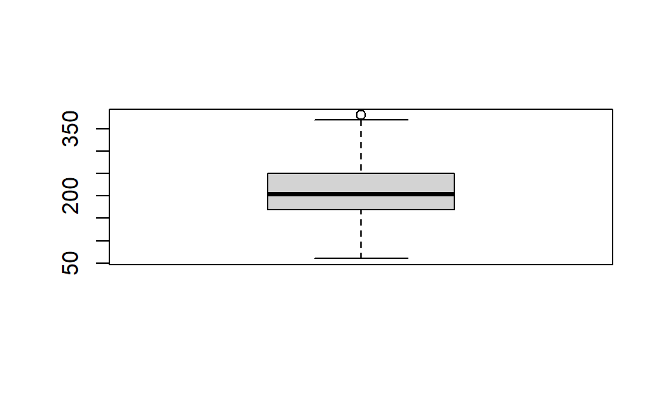

```r
weight<- fosdata::weight_estimate$mean200
boxplot(weight)
```

```r
wilcox.test(weight, mu=200)
```

```
##
##  Wilcoxon signed rank test with continuity correction
##
## data:  weight
## V = 1708, p-value = 0.2052
## alternative hypothesis: true location is not equal to 200
```

### Problem 09

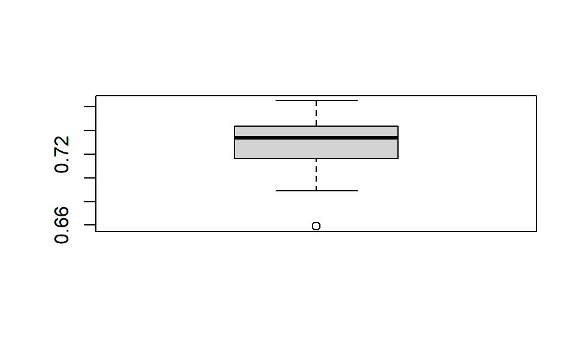

```r
sparrow<-Sleuth3::ex0221
boxplot(sparrow$Humerus[sparrow$Status == "Perished"])
```

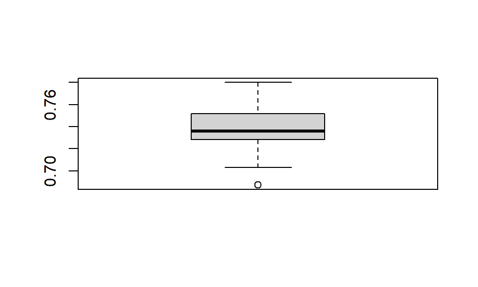

```r
boxplot(sparrow$Humerus[sparrow$Status == "Survived"])
```

b.

```r
wilcox.test(Humerus ~ Status, data=sparrow)
```

```
##
##  Wilcoxon rank sum test with continuity correction
##
## data:  Humerus by Status
## W = 331, p-value = 0.1718
## alternative hypothesis: true location shift is not equal to 0
```

3. No, there is not enough evidence to conclude that there is significant difference in Humerus length between the two populations.

### Problem 10

1. Yes, there is significant difference in the height of the flowers.

```r
flower<- Sleuth3::ex0428
wilcox.test(flower$Cross, flower$Self)
```

```
##
##  Wilcoxon rank sum test with continuity correction
##
## data:  flower$Cross and flower$Self
## W = 185.5, p-value = 0.002608
## alternative hypothesis: true location shift is not equal to 0
```

2. Both datasets are skew with one significant outlier.

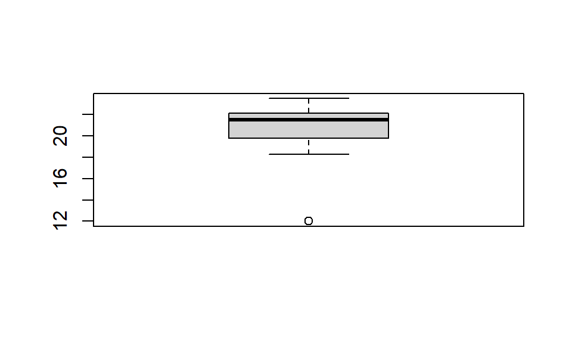

```r
boxplot(flower$Cross)
```

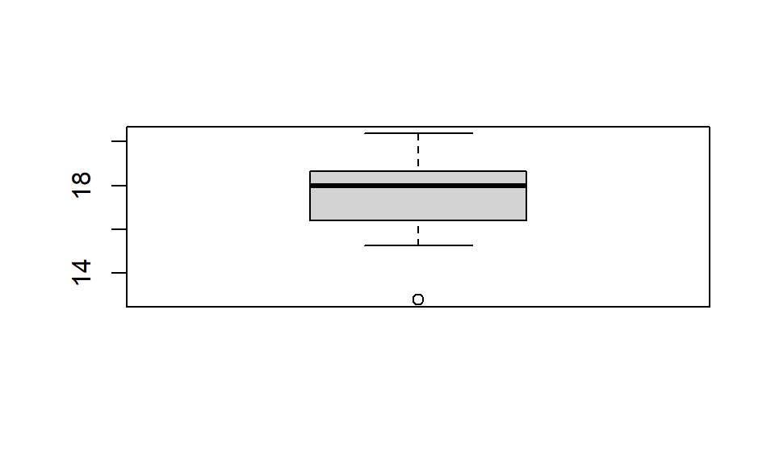

```r
boxplot(flower$Self)
```

### Problem 11

1. Hypothesis: There will be significant difference in antibody levels between the sample with malaria symptoms and the sample without.  
   P = 2.127e-05, reject the null, there is significant difference in antibody levels.

```r
malaria <- ISwR::malaria
wilcox.test(ab ~ mal, data=malaria)
```

```
##
##  Wilcoxon rank sum test with continuity correction
##
## data:  ab by mal
## W = 1533.5, p-value = 2.127e-05
## alternative hypothesis: true location shift is not equal to 0
```

2. No, the data is not normal and does not meet the assumptions of the t.test

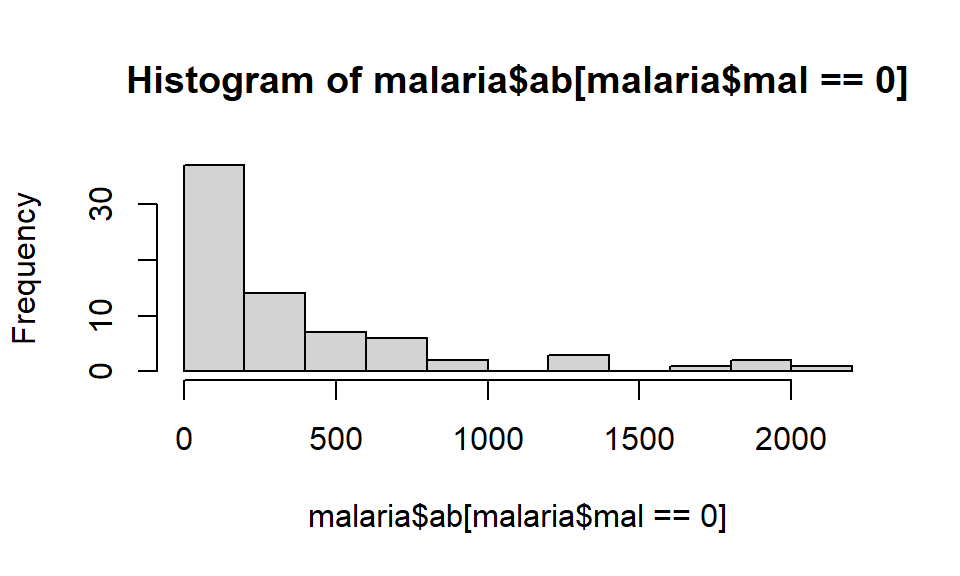

```r
hist(malaria$ab[malaria$mal == 0])
```

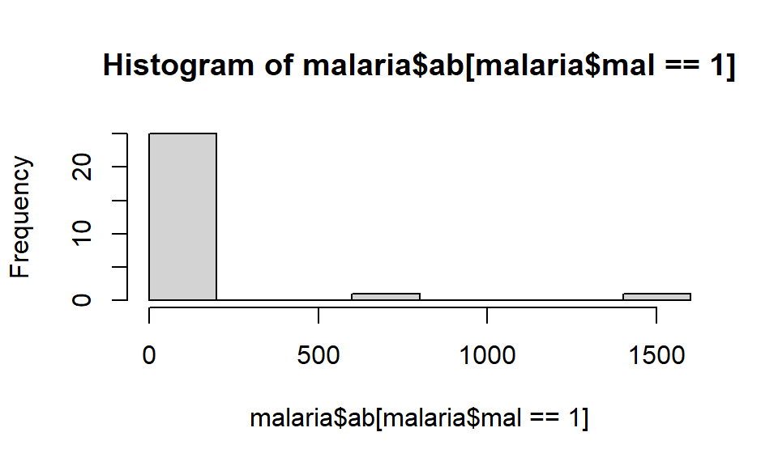

```r
hist(malaria$ab[malaria$mal == 1])
```

3. Taking the log of the data does make it roughly normal, making the t.test more viable.

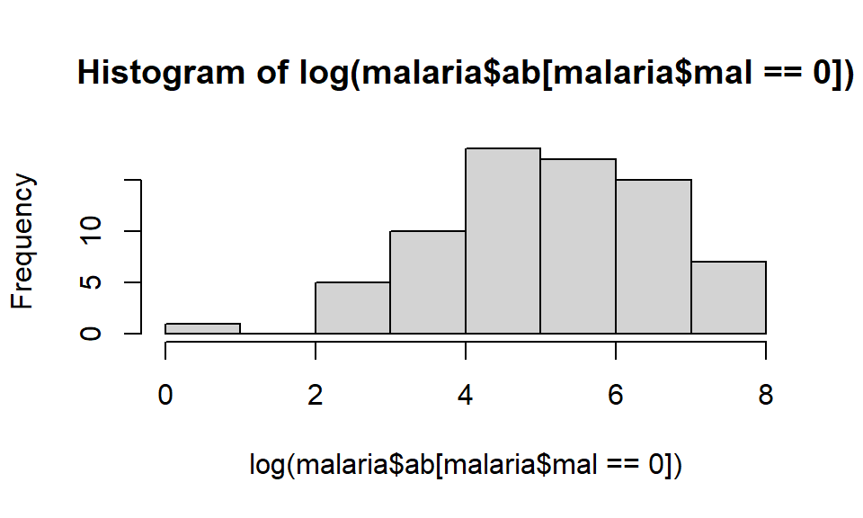

```r
hist(log(malaria$ab[malaria$mal == 0]))
```

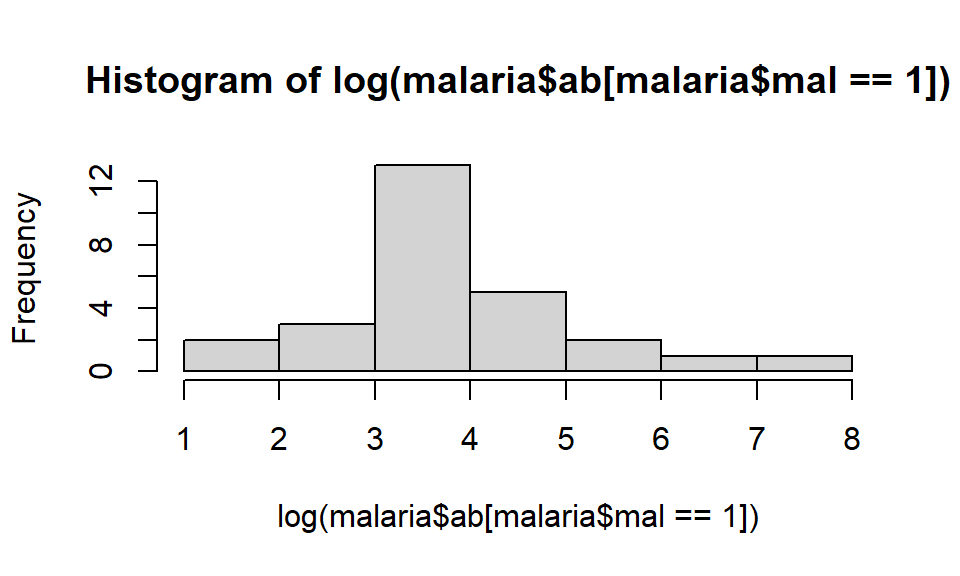

```r
hist(log(malaria$ab[malaria$mal == 1]))
```

4. Like the Wilcoxon test, this does show significance with a p-value of 2.376e-05. However, the p-value from the t.test is larger than the Wilcoxon p-value 2.127e-05, the difference is likely due to the fact that even the log of the data is still not completely normal.

```r
t.test(log(ab) ~ mal, data=malaria)
```

```
##
##  Welch Two Sample t-test
##
## data:  log(ab) by mal
## t = 4.6398, df = 52.256, p-value = 2.376e-05
## alternative hypothesis: true difference in means is not equal to 0
## 95 percent confidence interval:
##  0.7831352 1.9764775
## sample estimates:
## mean in group 0 mean in group 1
##        5.126524        3.746717
```

### Problem 15

```r
test<-replicate(10000,{x<-rnorm(100,0.1,1); t.test(x, mu=0)$p.value})
mean(test<0.05)
```

```
## [1] 0.1718
```

```r
test<-replicate(10000,{x<-rnorm(100,0.1,1); wilcox.test(x, mu=0)$p.value})
mean(test<0.05)
```

```
## [1] 0.1642
```

3. t.test: ~88% of the time

```r
test<-replicate(10000,{x<-rnorm(1000,0.1,1); t.test(x, mu=0)$p.value})
mean(test<0.05)
```

```
## [1] 0.8853
```

[output not shown]

```r
test<-replicate(10000,{x<-rnorm(1000,0.1,1); wilcox.test(x, mu=0)$p.value})
mean(test<0.05)
```

```
## [1] 0.8708
```

4. Since their accuracy is similar, anecdotally I’d suggest running t.test as wilcox.test took significantly longer with larger n.

### Problem 16

```r
pvals <- replicate(10000, {
  x <- rt(20, df=86)
  t.test(x, mu=1)$p.value
})
power<- mean(pvals < 0.05)
1 - power
```

```
## [1] 0.0149
```

```r
pvals <- replicate(10000, {
  x <- rt(20, df=86)
  wilcox.test(x, mu=1)$p.value
})
power<- mean(pvals < 0.05)
1 - power
```

```
## [1] 0.0189
```

6. It looks like t.test is more powerful when used on a t-distribution of data.